# Prediction Assignment Writeup

ongleongoh

Thursday, July 16, 2015

## Synopsis

The goal is to predict manner in which participants(A, B, C, D and E) did the exercise.

### Load Data

Load the pml-training.csv and pml-testing.csv.

```r
setwd("C:/Coursera/Practical Machine Learning/Project")
trainingScr <- read.csv("pml-training.csv", na.string=c("", "NA", "NULL", "#DIV/0!"))
testingScr <-  read.csv("pml-testing.csv" , na.string=c("", "NA", "NULL", "#DIV/0!"))
dim(trainingScr); dim(testingScr)
```

```
## [1] 19622   160
```

```
## [1]  20 160
```

### Data Cleaning

- Remove variables that have too many NA values for both training and test set.

```r
remove <- colSums(is.na(trainingScr))==0
training.RemoveNA <- trainingScr[, remove]
testing.RemoveNA <- testingScr[, remove]
dim(training.RemoveNA)
```

```
## [1] 19622    60
```

```r
dim(testing.RemoveNA)
```

```
## [1] 20 60
```

```r
table(training.RemoveNA$classe)
```

```
##
##    A    B    C    D    E
## 5580 3797 3422 3216 3607
```

- Remove “X”,“user_name”, “raw_timestamp_part_1”, “raw_timestamp_part_2”, “cvtd_timestamp”, “new_window”, “num_window” colums from the dataset since they are not relevant.

```r
remove <- c("X","user_name", "raw_timestamp_part_1", "raw_timestamp_part_2", "cvtd_timestamp", "new_window", "num_window")
training.Final <- training.RemoveNA[, -which(names(training.RemoveNA) %in% remove)]
testing.Final <- testing.RemoveNA[, -which(names(testing.RemoveNA) %in% remove)]
dim(training.Final)
```

```
## [1] 19622    53
```

### Partition data into training and test sets

Load the libraries and partition data to 60% training and 40% testing sets.

```r
library(caret)
library(randomForest)
library(doParallel)
inTraining <- createDataPartition(training.Final$classe, p=0.6, list=FALSE)
training <- training.Final[inTraining,]
testing <- training.Final[-inTraining,]
```

### Fitting Randaom Forests

Use Parallel Random Forest algorithm to fit the model.

```r
class <- training$classe
data  <- training[-ncol(training)] # remove the last column(classe)
registerDoParallel()
# Tried random forest method, parallel random forest and rpart method.
# rf <- train(classe~., data=training, method = "rf", tuneLength = 1, ntree = 80)
# rf <- train(classe ~ .,method="rpart",data=training)   # Accuracy : 0.4966 Not accurate.
rf <- train(data, class, method="parRF", tuneGrid=data.frame(mtry=5), trControl=trainControl(method="none"))
rf
```

```
## Parallel Random Forest
##
## 11776 samples
##    52 predictor
##     5 classes: 'A', 'B', 'C', 'D', 'E'
##
## No pre-processing
## Resampling: None
```

```r
rf$finalModel
```

```
##
## Call:
##  randomForest(x = "x", y = "y", ntree = 84, mtry = 5)
##                Type of random forest: classification
##                      Number of trees: 252
## No. of variables tried at each split: 5
```

Number of trees: 252

No. of variables tried at each split: 5

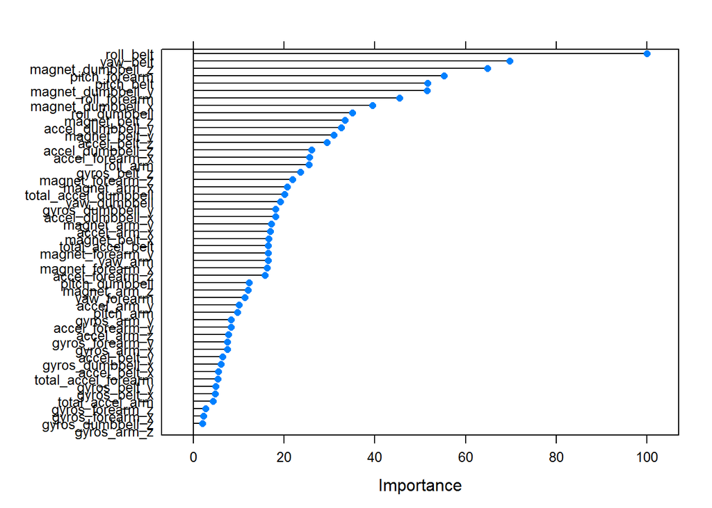

```r
plot(varImp(rf))
```

Generate the confusion matrix to prediect the testing set

```r
testingPred <- predict(rf, newdata=testing)
confMatrix <- confusionMatrix(testingPred, testing$classe)
confMatrix
```

```
## Confusion Matrix and Statistics
##
##           Reference
## Prediction    A    B    C    D    E
##          A 2231    8    0    0    0
##          B    0 1509   14    0    0
##          C    0    1 1353   23    0
##          D    1    0    1 1262    0
##          E    0    0    0    1 1442
##
## Overall Statistics
##
##                Accuracy : 0.9938
##                  95% CI : (0.9918, 0.9954)
##     No Information Rate : 0.2845
##     P-Value [Acc > NIR] : < 2.2e-16
##
##                   Kappa : 0.9921
##  Mcnemar's Test P-Value : NA
##
## Statistics by Class:
##
##                      Class: A Class: B Class: C Class: D Class: E
## Sensitivity            0.9996   0.9941   0.9890   0.9813   1.0000
## Specificity            0.9986   0.9978   0.9963   0.9997   0.9998
## Pos Pred Value         0.9964   0.9908   0.9826   0.9984   0.9993
## Neg Pred Value         0.9998   0.9986   0.9977   0.9964   1.0000
## Prevalence             0.2845   0.1935   0.1744   0.1639   0.1838
## Detection Rate         0.2843   0.1923   0.1724   0.1608   0.1838
## Detection Prevalence   0.2854   0.1941   0.1755   0.1611   0.1839
## Balanced Accuracy      0.9991   0.9959   0.9927   0.9905   0.9999
```

```r
confMatrix$overall
```

```
##       Accuracy          Kappa  AccuracyLower  AccuracyUpper   AccuracyNull
##      0.9937548      0.9920992      0.9917518      0.9953763      0.2844762
## AccuracyPValue  McnemarPValue
##      0.0000000            NaN
```

Accuracy: 99.3% a very accurate estimate.

### Conclusions

The confusion matrix for this model using parallel random forest is very accurate at 99.3%.

### Submit results of Test set.

```r
pml_write_files = function(x){
  n = length(x)
  for(i in 1:n){
    filename = paste0("problem_id_",i,".txt")
    write.table(x[i],file=filename,quote=FALSE,row.names=FALSE,col.names=FALSE)
  }
}

answers <- predict(rf, testing.Final)
answers
```

```
##  [1] B A B A A E D B A A B C B A E E A B B B
## Levels: A B C D E
```

```r
pml_write_files(answers)
```